# The Economic Endgame

2025-12-13 · Shammah Chancellor

Why AI displacement is different, and what we must do before it’s too late

Also on [Substack](https://shablag.substack.com/p/the-economic-endgame)

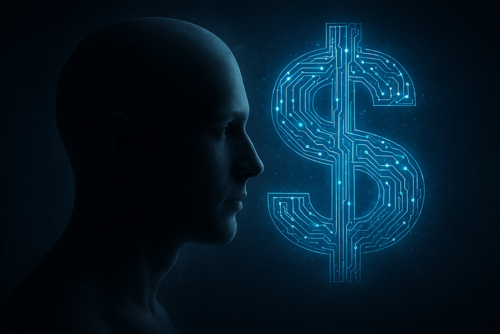

Cover Image

## Introduction

Chancellor challenges the assumption that AI-driven displacement mirrors past technological transitions. He notes that Eric Schmidt claimed displaced workers historically created more jobs than were destroyed, but argues this parallel fails under current conditions.

## The Fundamental Difference

The author contends that “historically, we had growing populations that needed more consumable goods – this is ceasing to be true.” Previous economic transitions succeeded because labor shortages existed elsewhere. Farm workers became factory workers; factory workers shifted to services; service workers transitioned into cognitive roles. This progression assumed surplus unmet demand for human intelligence and expanding population.

Chancellor emphasizes the fundamental difference: “In a world where AI is more intelligent than the smartest human beings, and also displaces all non-regulated knowledge work, what kind of employment are people supposed to find?”

## The Timeline

He projects rapid timeline concerns, stating knowledge automation “will accelerate dramatically over the next 3-5 years as AI capabilities compound.”

Unlike previous technological shifts that took generations, AI capability improvements compound rapidly. Each advance in AI capability accelerates the next, creating exponential rather than linear change. This compression of timeline leaves little room for organic economic adjustment or retraining programs.

## Historical Precedent Fails

Previous technological transitions succeeded because:

1. **Growing populations** created expanding demand for goods and services
2. **Unmet human needs** absorbed displaced workers into new sectors
3. **Geographic expansion** provided new markets and opportunities
4. **Generational timescales** allowed gradual adaptation
5. **Human intelligence remained scarce** and valuable

None of these conditions hold for AI displacement:

1. **Demographic decline** in developed nations reduces demand growth
2. **Service sector saturation** leaves few remaining labor-intensive sectors
3. **Geographic limits reached** - no new frontier markets to develop
4. **Rapid deployment** of AI happens in years, not generations
5. **AI exceeds human intelligence** in most economically valuable domains

[figure not shown]

## The Deflationary Spiral

Chancellor warns of a deflationary spiral if mass unemployment occurs without intervention:

- Workers lose income and purchasing power
- Reduced consumption decreases business revenue
- Companies reduce production and lay off more workers
- Further consumption decline creates feedback loop
- Economic activity contracts despite productive capacity

This differs from historical unemployment because AI doesn’t consume goods and services. Previous automation replaced human labor but created jobs in production, maintenance, and operation of the new technology. AI automation creates minimal compensating employment.

## Economic Solutions

### Why This Specific Mechanism

1. **Maintains purchasing power** across the economy during labor displacement
2. **Withdraws capital from circulation** to prevent inflationary effects
3. **Taxes wealth rather than income** since income becomes meaningless in post-labor economy
4. **Preserves capitalism** by maintaining consumer markets and price signals
5. **Scales with need** as more workers are displaced, more wealth is redistributed

### The Mathematics

A 1% annual wealth tax on net worth exceeding $10 million would:

- Affect primarily the ultra-wealthy who benefit most from AI productivity gains
- Generate substantial revenue without confiscatory rates
- Leave incentives for wealth creation largely intact
- Grow naturally as AI increases economic productivity

The $10 million threshold ensures:

- Middle-class retirement savings untouched
- Small business owners unaffected
- Successful professionals retain incentives
- Only those with truly exceptional wealth contribute

### Why Not Other Approaches

Chancellor dismisses several alternatives:

**Retraining Programs**: Cannot prepare workers for jobs that don’t exist or that AI performs better

**Job Guarantee Programs**: Create make-work that adds no economic value and may damage dignity

**Means-Tested Welfare**: Creates bureaucracy, stigma, and perverse incentives against work

**Raising Minimum Wage**: Accelerates automation and reduces employment opportunities

**Labor Market Restrictions**: Reduces economic efficiency without solving displacement problem

## Capitalism Reformed, Not Abandoned

Chancellor ultimately advocates capitalism’s reformation rather than abandonment, urging voters to support leaders who comprehend AI’s inevitability and champion monetary restructuring.

He argues that capitalism’s core mechanisms—price signals, consumer choice, competitive markets—remain valuable even in a highly automated economy. What must change is how purchasing power is distributed when most people can no longer sell their labor.

## The Stakes

Without intervention, Chancellor warns of:

- **Mass unemployment** as AI exceeds human capability across cognitive domains
- **Economic collapse** as consumer purchasing power evaporates
- **Social instability** as traditional paths to dignity and purpose disappear
- **Political extremism** as desperate populations seek radical solutions
- **Potential violence** if economic desperation reaches critical thresholds

## The Window for Action

The essay emphasizes urgency: implementation of economic reforms takes time, requiring:

- Public debate and consensus building
- Legislative process and policy design
- Administrative infrastructure creation
- Gradual rollout to minimize disruption

Starting this process now, before mass displacement occurs, provides opportunity for measured implementation. Waiting until crisis hits leaves only emergency measures with unpredictable consequences.

## Call to Action

Chancellor urges readers to:

- **Recognize AI displacement as fundamentally different** from previous technological change
- **Support economic reforms** that maintain purchasing power during transition
- **Advocate for wealth taxation** to fund universal basic income
- **Pressure political leaders** to address AI economics seriously
- **Prepare personally** for rapid economic transformation

## Conclusion

The essay concludes that AI represents not merely another technological shift but an economic endgame requiring fundamental restructuring of how purchasing power is distributed. The choice is not between capitalism and socialism, but between capitalism reformed to accommodate post-labor economics or economic collapse followed by unpredictable radical change.

Time to implement measured reforms is limited. The window for avoiding crisis through preparation is closing as AI capabilities accelerate. Political will to address this reality before crisis hits remains the primary obstacle.

Read and subscribe on [Substack](https://shablag.substack.com/p/the-economic-endgame)